# R Notebook

```r
library(tidyverse)
library(dplyr)
library(ggplot2)
library(lubridate)
#install.packages("fredr")
library(fredr)
#install.packages("DescTools")
library(DescTools)
#install.packages("pracma")
library(pracma)
#install.packages("seastests")
library(seastests)
#install.packages(c("seasonal", "x13binary"))
library(seasonal)
```

# Task 1

Notes

Q1: 01-01, Q2: 04-01, Q3: 07-01, Q4: 10-01

```r
api_key <- '3949fd9fcfaa43711339ce7b8a243180'

fredr_set_key(api_key)


# Federal Funds Effective Rate (FFER)
ffer_full <- fredr(
  series_id = "FEDFUNDS",
  frequency = "q",              # quarterly
  aggregation_method = "avg",
  observation_start = as.Date("1980-01-01")
)

head(ffer_full)
```

| date | series_id | value | realtime_start | realtime_end |
| --- | --- | --- | --- | --- |
| 1980-01-01 | FEDFUNDS | 15.05 | 2025-10-26 | 2025-10-26 |
| 1980-04-01 | FEDFUNDS | 12.69 | 2025-10-26 | 2025-10-26 |
| 1980-07-01 | FEDFUNDS | 9.84 | 2025-10-26 | 2025-10-26 |
| 1980-10-01 | FEDFUNDS | 15.85 | 2025-10-26 | 2025-10-26 |
| 1981-01-01 | FEDFUNDS | 16.57 | 2025-10-26 | 2025-10-26 |
| 1981-04-01 | FEDFUNDS | 17.78 | 2025-10-26 | 2025-10-26 |

```r
# Personal Consumption Expenditures Index (PCEPI) - Inflation measure
pcepi_full <- fredr(
  series_id = "PCEPI",
  frequency = "q",
  aggregation_method = "avg",
  observation_start = as.Date("1980-01-01")
)

head(pcepi_full)
```

| date | series_id | value | realtime_start | realtime_end |
| --- | --- | --- | --- | --- |
| 1980-01-01 | PCEPI | 37.546 | 2025-10-26 | 2025-10-26 |
| 1980-04-01 | PCEPI | 38.464 | 2025-10-26 | 2025-10-26 |
| 1980-07-01 | PCEPI | 39.364 | 2025-10-26 | 2025-10-26 |
| 1980-10-01 | PCEPI | 40.338 | 2025-10-26 | 2025-10-26 |
| 1981-01-01 | PCEPI | 41.384 | 2025-10-26 | 2025-10-26 |
| 1981-04-01 | PCEPI | 42.078 | 2025-10-26 | 2025-10-26 |

```r
# Real GDP
gdp_full <- fredr(
  series_id = "GDPC1",
  frequency = "q",
  aggregation_method = "avg",
  observation_start = as.Date("1980-01-01")
)

head(gdp_full)
```

| date | series_id | value | realtime_start | realtime_end |
| --- | --- | --- | --- | --- |
| 1980-01-01 | GDPC1 | 7341.557 | 2025-10-26 | 2025-10-26 |
| 1980-04-01 | GDPC1 | 7190.289 | 2025-10-26 | 2025-10-26 |
| 1980-07-01 | GDPC1 | 7181.743 | 2025-10-26 | 2025-10-26 |
| 1980-10-01 | GDPC1 | 7315.677 | 2025-10-26 | 2025-10-26 |
| 1981-01-01 | GDPC1 | 7459.022 | 2025-10-26 | 2025-10-26 |
| 1981-04-01 | GDPC1 | 7403.745 | 2025-10-26 | 2025-10-26 |

```r
# Potential Real GDP
pot_gdp_full <- fredr(
  series_id = "GDPPOT",
  frequency = "q",
  aggregation_method = "avg",
  observation_start = as.Date("1980-01-01")
)

head(pot_gdp_full)
```

| date | series_id | value | realtime_start | realtime_end |
| --- | --- | --- | --- | --- |
| 1980-01-01 | GDPPOT | 7326.394 | 2025-10-26 | 2025-10-26 |
| 1980-04-01 | GDPPOT | 7367.995 | 2025-10-26 | 2025-10-26 |
| 1980-07-01 | GDPPOT | 7403.121 | 2025-10-26 | 2025-10-26 |
| 1980-10-01 | GDPPOT | 7440.202 | 2025-10-26 | 2025-10-26 |
| 1981-01-01 | GDPPOT | 7464.041 | 2025-10-26 | 2025-10-26 |
| 1981-04-01 | GDPPOT | 7511.001 | 2025-10-26 | 2025-10-26 |

```r
NA
NA
```

```r
# Add pct_chg_pce col to PCE series
t_val <- pcepi_full$value
t_minus_one_val <- lag(pcepi_full$value, 1)
pcepi_full$pct_chg_pce <- (t_val - t_minus_one_val) / t_minus_one_val


gdp_merged <- inner_join(gdp_full, pot_gdp_full, by='date')

# Add Output Gap col to GDP series
gdp_merged$output_gap <- (gdp_merged$value.x - gdp_merged$value.y) * 100 / gdp_merged$value.y

gdp_merged$series_id <- 'OUTPUTGAP'
gdp_merged <- gdp_merged %>% rename(realtime_start = realtime_start.x, realtime_end = realtime_end.x, value=output_gap)

output_gap <- gdp_merged %>% select(date, series_id, value, realtime_start, realtime_end)
```

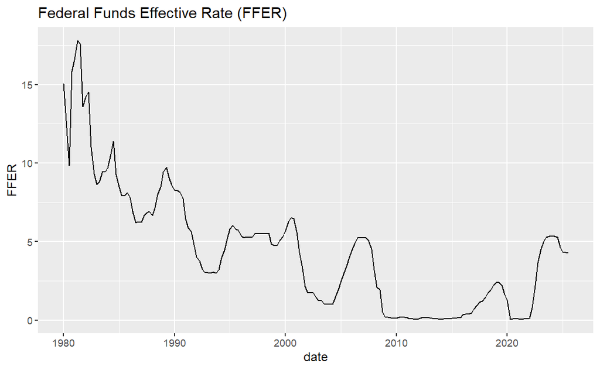

```r
ffer_full %>%
  ggplot(aes(x = date, y = value)) +
  geom_line() +
  labs(title = "Federal Funds Effective Rate (FFER)",
       x = "date",
       y = 'FFER')
```

```r
ffer_full %>%
  summarize(
    mean = mean(value, na.rm = TRUE),
    var_value  = var(value, na.rm = TRUE),
    sd_value   = sd(value, na.rm = TRUE),
    n_obs      = n()
  )
```

| mean | var_value | sd_value | n_obs |
| --- | --- | --- | --- |
| 4.422514 | 15.2554 | 3.905816 | 183 |

```r
NA
```

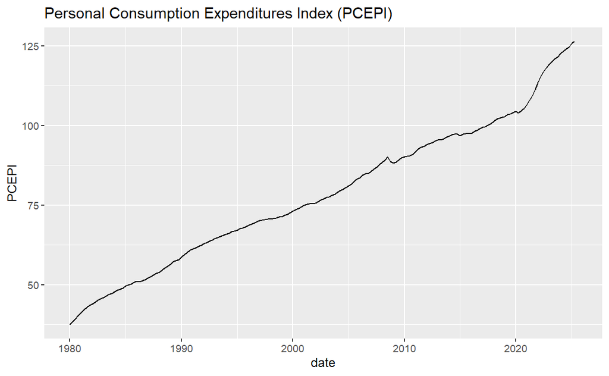

```r
pcepi_full %>%
  ggplot(aes(x = date, y = value)) +
  geom_line() +
  labs(title = "Personal Consumption Expenditures Index (PCEPI)",
       x = "date",
       y = 'PCEPI')
```

```r
pcepi_full %>%
  summarize(
    mean = mean(value, na.rm = TRUE),
    var_value  = var(value, na.rm = TRUE),
    sd_value   = sd(value, na.rm = TRUE),
    n_obs      = n()
  )
```

| mean | var_value | sd_value | n_obs |
| --- | --- | --- | --- |
| 78.62457 | 501.4784 | 22.39371 | 183 |

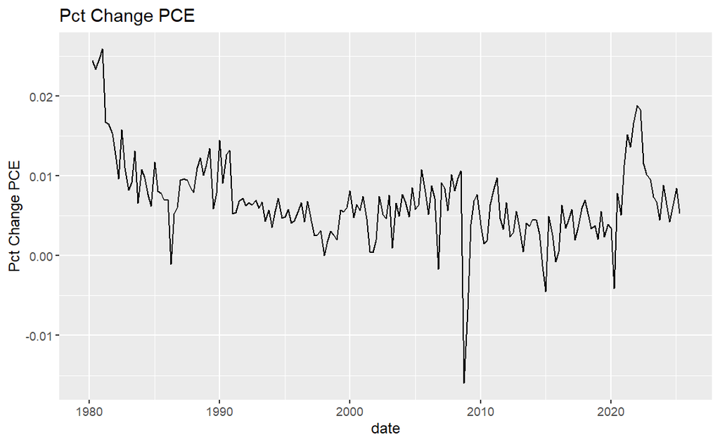

```r
pcepi_full %>%
  ggplot(aes(x = date, y = pct_chg_pce)) +
  geom_line() +
  labs(title = "Pct Change PCE",
       x = "date",
       y = 'Pct Change PCE')
```

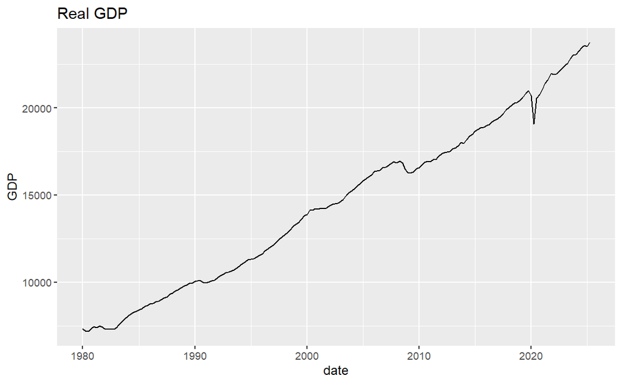

```r
# Do regular GDP, POT GDP, and output gap

gdp_full %>%
  ggplot(aes(x = date, y = value)) +
  geom_line() +
  labs(title = "Real GDP ",
       x = "date",
       y = 'GDP')
```

```r
gdp_full %>%
  summarize(
    mean = mean(value, na.rm = TRUE),
    var_value  = var(value, na.rm = TRUE),
    sd_value   = sd(value, na.rm = TRUE),
    n_obs      = n()
  )
```

| mean | var_value | sd_value | n_obs |
| --- | --- | --- | --- |
| 14531.84 | 22626642 | 4756.747 | 182 |

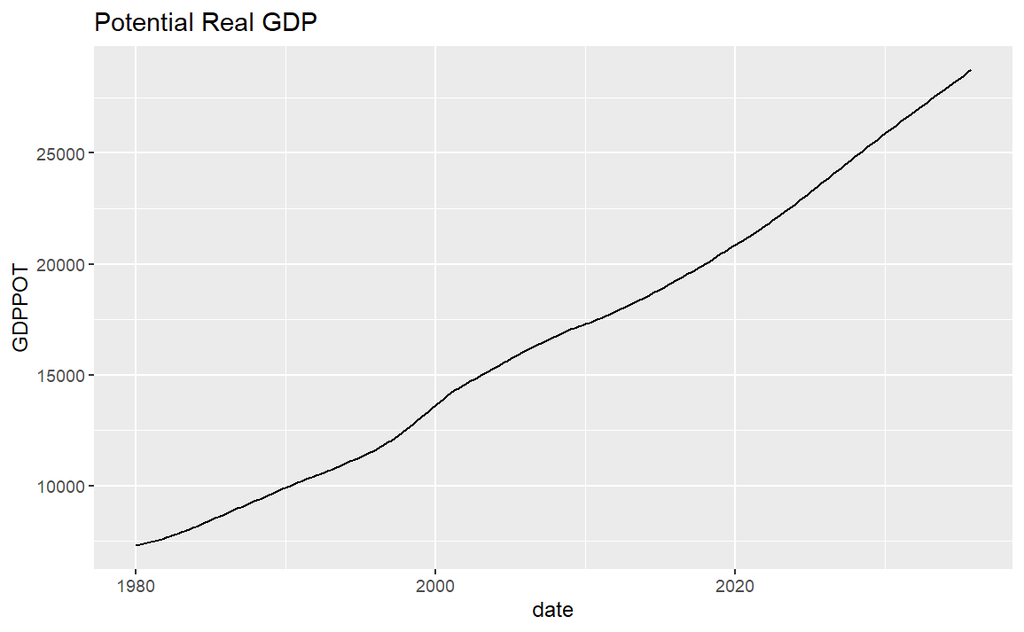

```r
pot_gdp_full %>%
  ggplot(aes(x = date, y = value)) +
  geom_line() +
  labs(title = "Potential Real GDP ",
       x = "date",
       y = 'GDPPOT')
```

```r
pot_gdp_full %>%
  summarize(
    mean = mean(value, na.rm = TRUE),
    var_value  = var(value, na.rm = TRUE),
    sd_value   = sd(value, na.rm = TRUE),
    n_obs      = n()
  )
```

| mean | var_value | sd_value | n_obs |
| --- | --- | --- | --- |
| 16794.26 | 39104341 | 6253.346 | 224 |

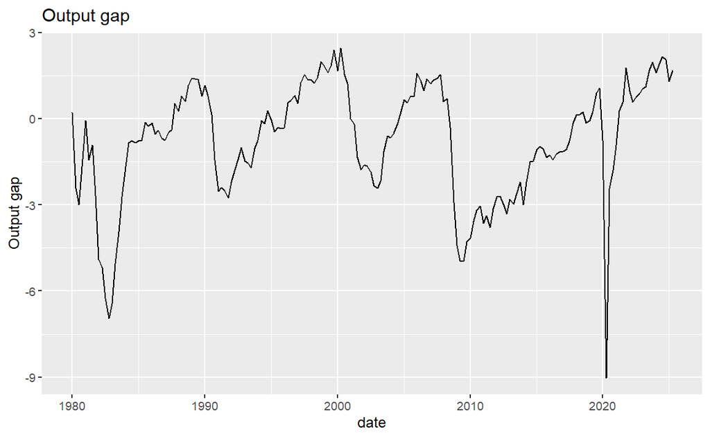

```r
output_gap %>%
  ggplot(aes(x = date, y = value)) +
  geom_line() +
  labs(title = "Output gap",
       x = "date",
       y = 'Output gap')
```

# Task 2

**2.1: Frequency Alignment (Resampling)**

Based on the format of the API call to FRED, data is received at a quarterly cadence, with an average over all months in the quarter calculated and returned in the dataframe. No resampling was done.

```r
ensure_same_dates <- ffer_full %>%
  full_join(gdp_full, by='date') %>%
  full_join(pcepi_full, by='date') %>%
  full_join(pot_gdp_full, by='date') %>%
  full_join(output_gap, by='date')

# Filter all to 2025-04-01 after visual examination of the data
ffer_full <- ffer_full %>% filter(date <= as.Date('2025-04-01'))
pcepi_full <- pcepi_full %>% filter(date <= as.Date('2025-04-01'))
pot_gdp_full <- pot_gdp_full %>% filter(date <= as.Date('2025-04-01'))
output_gap <- output_gap %>% filter(date <= as.Date('2025-04-01'))
```

**2.2: Outlier Detection & Treatment**

Method: Hampel filter

To detect outliers, we’ve chosen to use the Hampel filter. We prefer this method because based on a visual examination of FFER, PECPI, and GDP data, scores appear to be mostly following either an upward trend or a fluctuating downward trend, with few outliers. The outliers that do appear (i.e. in Real GDP around 2020) are within the data (as opposed to on the upper and lower ends of the data). Thus, this would not be caught by winsorization. The rolling window calculations from a Hampel filter (relying on deviations from a median) would catch these outliers and smooth out the data. Z-scores, as well, is best suited to normally distributed data, which we don’t have.

Outlier Detection

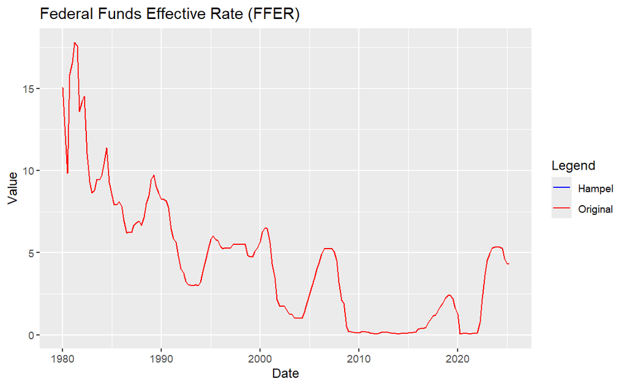

```r
ffer_full$hampel_val <- hampel(ffer_full$value, k = 5)[[1]]

ffer_full %>%
  ggplot(aes(x = date)) +
  geom_line(aes(y = hampel_val, color = "Hampel")) +
  geom_line(aes(y = value, color = "Original")) +
  labs(title = "Federal Funds Effective Rate (FFER)",
       x = "Date",
       y = "Value") +
  scale_color_manual(values = c("Hampel" = "blue", "Original" = "red"),
                     name = "Legend")
```

```r
NA
NA
```

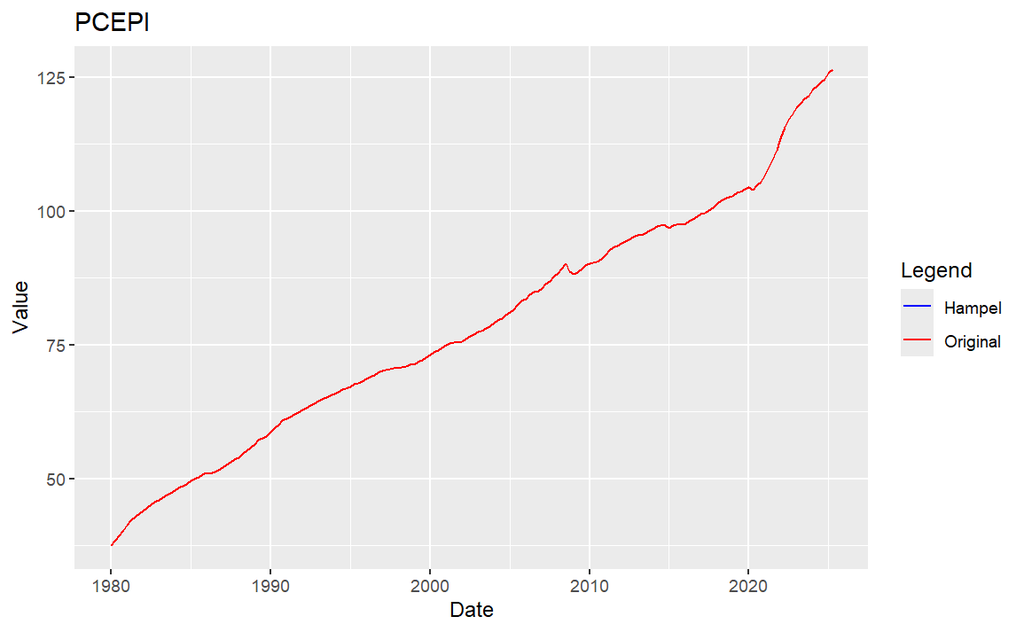

```r
pcepi_full$hampel_val <- hampel(pcepi_full$value, k = 5, )[[1]]

pcepi_full %>%
  ggplot(aes(x = date)) +
  geom_line(aes(y = hampel_val, color = "Hampel")) +
  geom_line(aes(y = value, color = "Original")) +
  labs(title = "PCEPI",
       x = "Date",
       y = "Value") +
  scale_color_manual(values = c("Hampel" = "blue", "Original" = "red"),
                     name = "Legend")
```

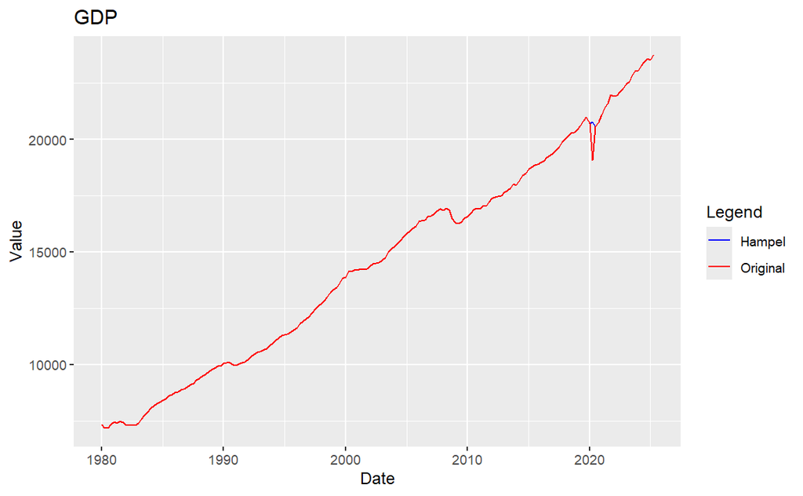

```r
gdp_full$hampel_val <- hampel(gdp_full$value, k = 5, )[[1]]

gdp_full %>%
  ggplot(aes(x = date)) +
  geom_line(aes(y = hampel_val, color = "Hampel")) +
  geom_line(aes(y = value, color = "Original")) +
  labs(title = "GDP",
       x = "Date",
       y = "Value") +
  scale_color_manual(values = c("Hampel" = "blue", "Original" = "red"),
                     name = "Legend")
```

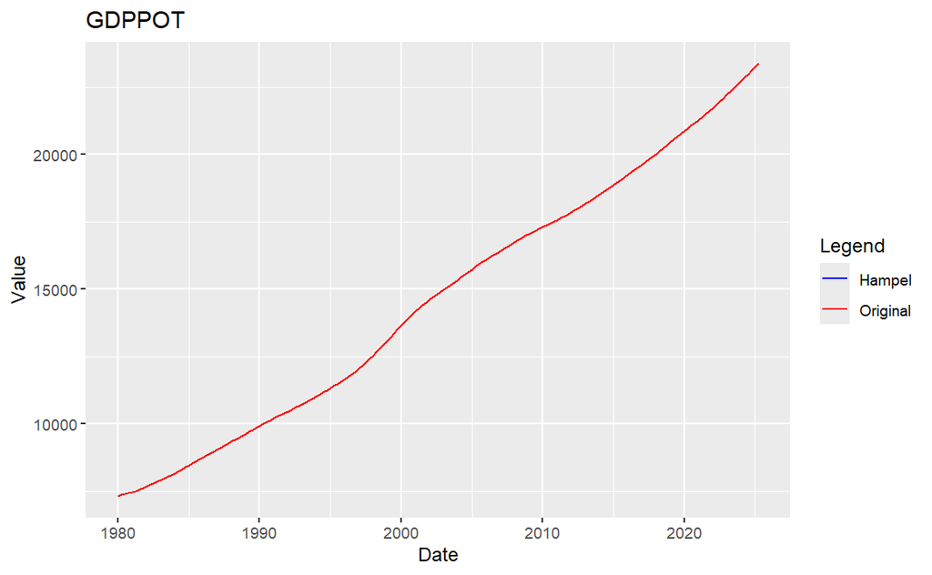

```r
pot_gdp_full$hampel_val <- hampel(pot_gdp_full$value, k = 5, )[[1]]

pot_gdp_full %>%
  ggplot(aes(x = date)) +
  geom_line(aes(y = hampel_val, color = "Hampel")) +
  geom_line(aes(y = value, color = "Original")) +
  labs(title = "GDPPOT",
       x = "Date",
       y = "Value") +
  scale_color_manual(values = c("Hampel" = "blue", "Original" = "red"),
                     name = "Legend")
```

```r
output_gap$value <- (gdp_full$hampel_val - pot_gdp_full$hampel_val) * 100 / pot_gdp_full$hampel_val
```

**2.3: Seasonal Adjustment**

Detection

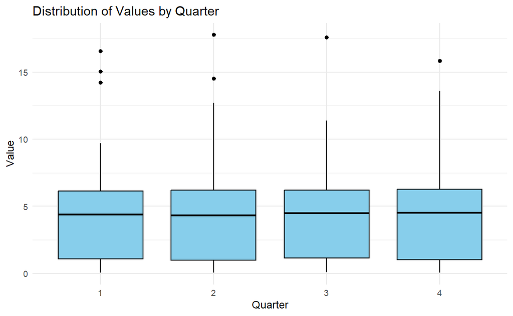

```r
ffer_full <- ffer_full %>% mutate(q = quarter(date))


ffer_full$q_factor <- factor(ffer_full$q, levels = c("1", "2", "3", "4"))

ggplot(ffer_full, aes(x = q_factor, y = value)) +
  geom_boxplot(fill = "skyblue", color = "black") +
  labs(title = "Distribution of Values by Quarter",
       x = "Quarter",
       y = "Value") +
  theme_minimal()
```

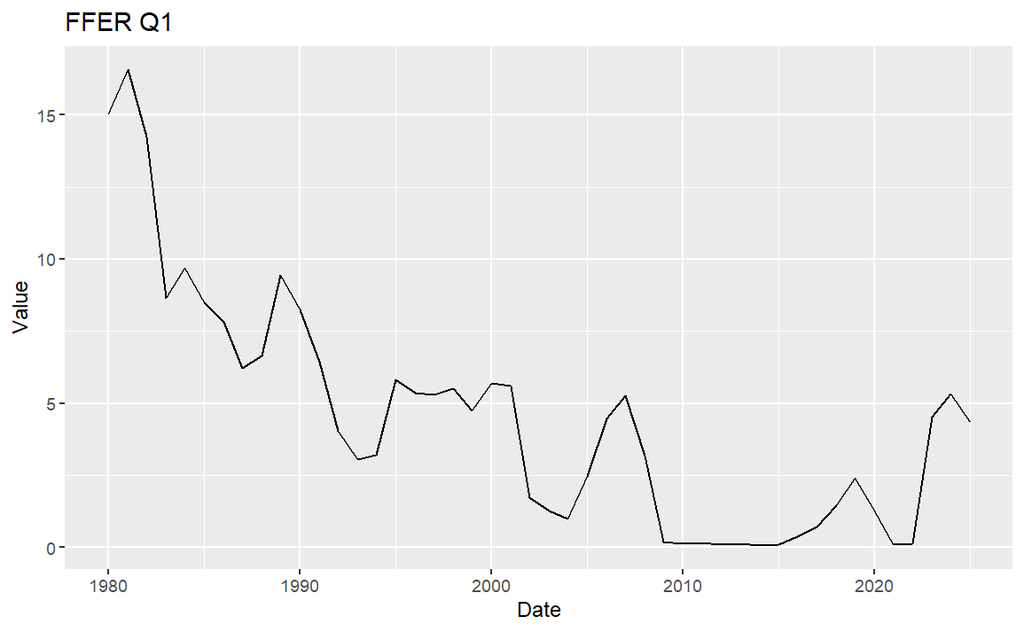

```r
ffer_full %>% filter(q == 1) %>% ggplot(aes(x=date, y=hampel_val)) + geom_line() + labs(title = "FFER Q1", x = "Date", y = "Value")
```

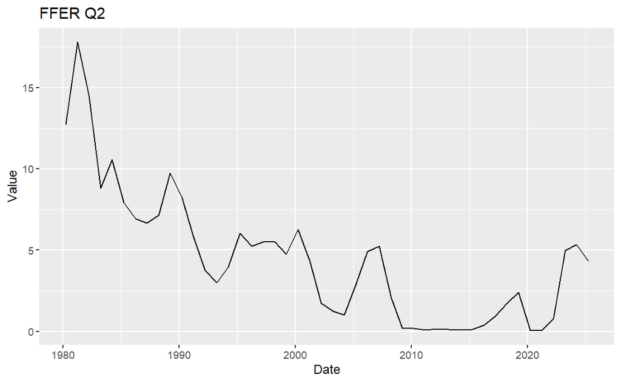

```r
ffer_full %>% filter(q == 2) %>% ggplot(aes(x=date, y=hampel_val)) + geom_line() + labs(title = "FFER Q2", x = "Date", y = "Value")
```

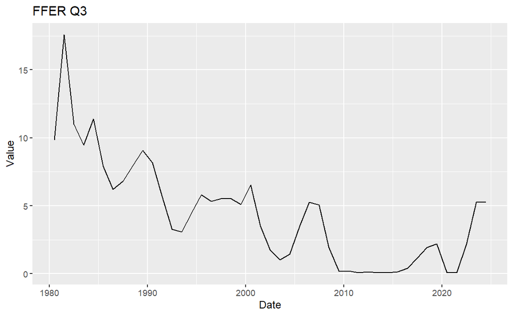

```r
ffer_full %>% filter(q == 3) %>% ggplot(aes(x=date, y=hampel_val)) + geom_line() + labs(title = "FFER Q3", x = "Date", y = "Value")
```

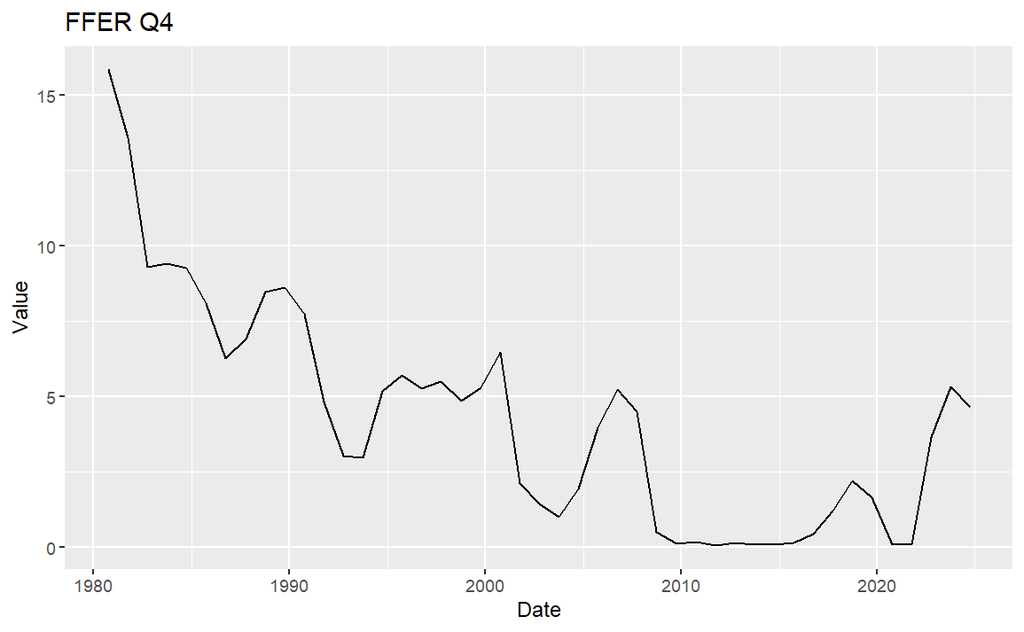

```r
ffer_full %>% filter(q == 4) %>% ggplot(aes(x=date, y=hampel_val)) + geom_line() + labs(title = "FFER Q4", x = "Date", y = "Value")
```

```r
start_year <- 1980
start_quarter <- 1

ffer_ts <- ts(ffer_full$hampel_val, start = c(start_year, start_quarter), frequency=4)

qs(ffer_ts)
```

```
Error in udg(x, qs.var, fail = FALSE) : inherits(x, "seas") is not TRUE
```

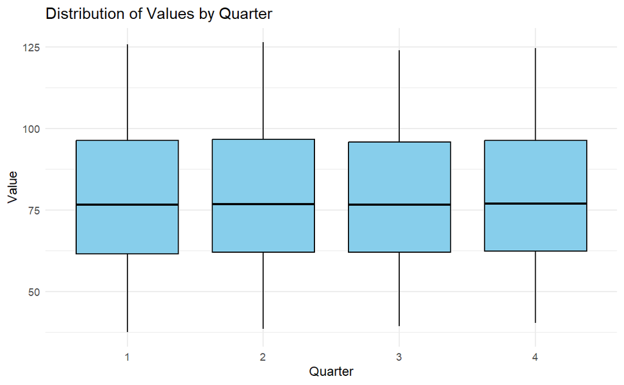

```r
pcepi_full <- pcepi_full %>% mutate(q = quarter(date))

pcepi_full$q_factor <- factor(pcepi_full$q, levels = c("1", "2", "3", "4"))

ggplot(pcepi_full, aes(x = q_factor, y = value)) +
  geom_boxplot(fill = "skyblue", color = "black") +
  labs(title = "Distribution of Values by Quarter",
       x = "Quarter",
       y = "Value") +
  theme_minimal()
```

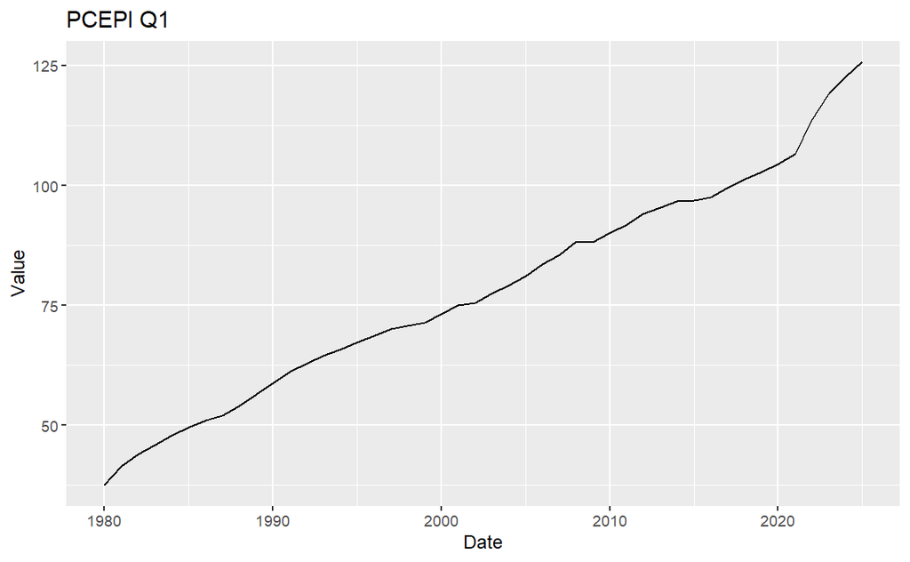

```r
pcepi_full %>% filter(q == 1) %>% ggplot(aes(x=date, y=hampel_val)) + geom_line() + labs(title = "PCEPI Q1", x = "Date", y = "Value")
```

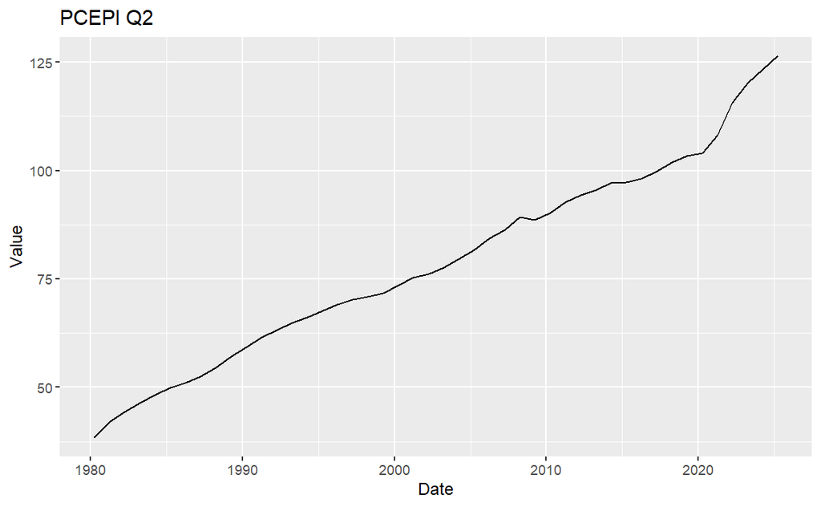

```r
pcepi_full %>% filter(q == 2) %>% ggplot(aes(x=date, y=hampel_val)) + geom_line() + labs(title = "PCEPI Q2", x = "Date", y = "Value")
```

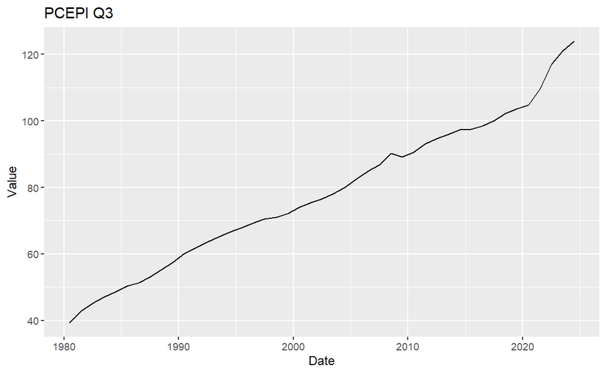

```r
pcepi_full %>% filter(q == 3) %>% ggplot(aes(x=date, y=hampel_val)) + geom_line() + labs(title = "PCEPI Q3", x = "Date", y = "Value")
```

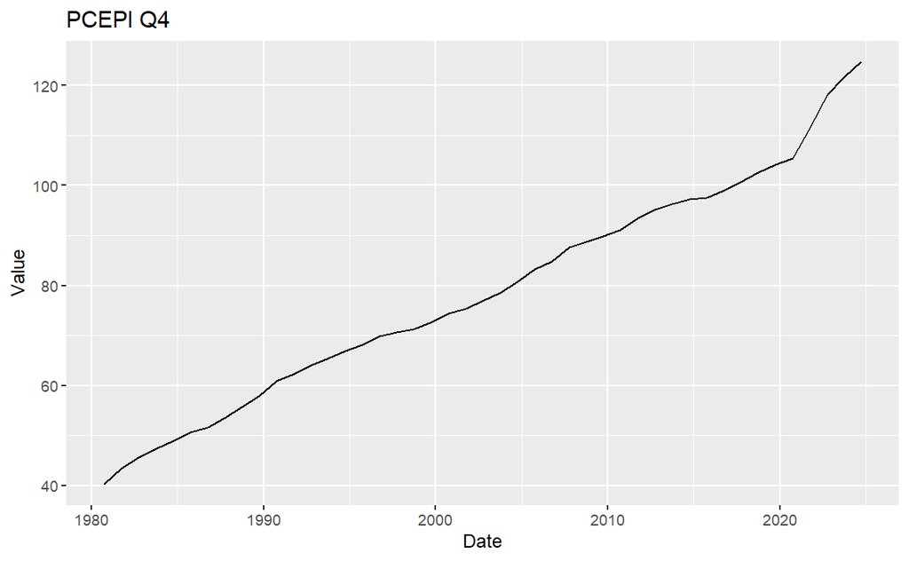

```r
pcepi_full %>% filter(q == 4) %>% ggplot(aes(x=date, y=hampel_val)) + geom_line() + labs(title = "PCEPI Q4", x = "Date", y = "Value")
```

```r
start_year <- 1980
start_quarter <- 1

pcepi_ts <- ts(pcepi_full$hampel_val, start = c(start_year, start_quarter), frequency=4)

qs(pcepi_ts)
```

```
Error in udg(x, qs.var, fail = FALSE) : inherits(x, "seas") is not TRUE
```

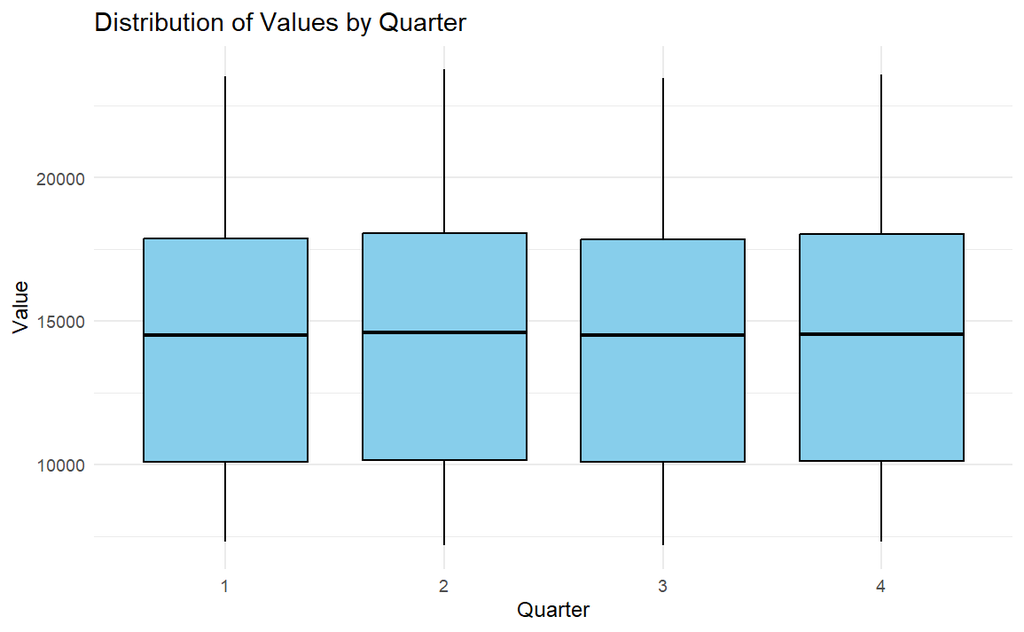

```r
gdp_full <- gdp_full %>% mutate(q = quarter(date))

gdp_full$q_factor <- factor(gdp_full$q, levels = c("1", "2", "3", "4"))

ggplot(gdp_full, aes(x = q_factor, y = value)) +
  geom_boxplot(fill = "skyblue", color = "black") +
  labs(title = "Distribution of Values by Quarter",
       x = "Quarter",
       y = "Value") +
  theme_minimal()
```

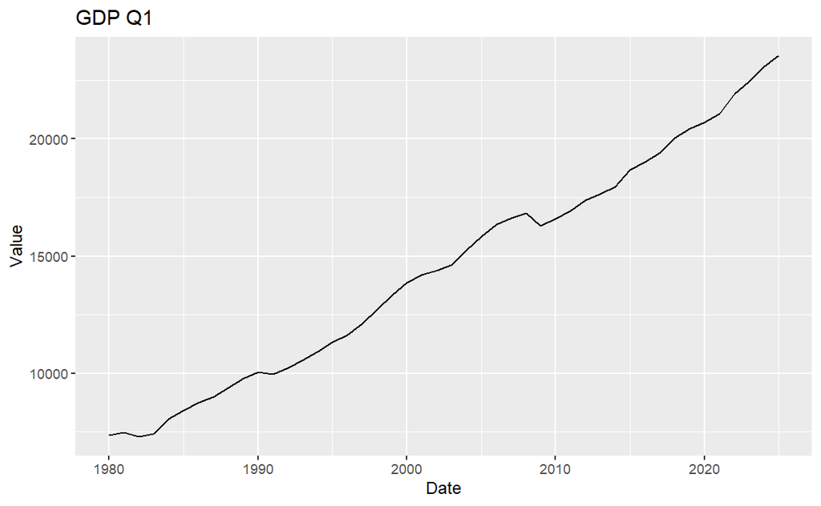

```r
gdp_full %>% filter(q == 1) %>% ggplot(aes(x=date, y=hampel_val)) + geom_line() + labs(title = "GDP Q1", x = "Date", y = "Value")
```

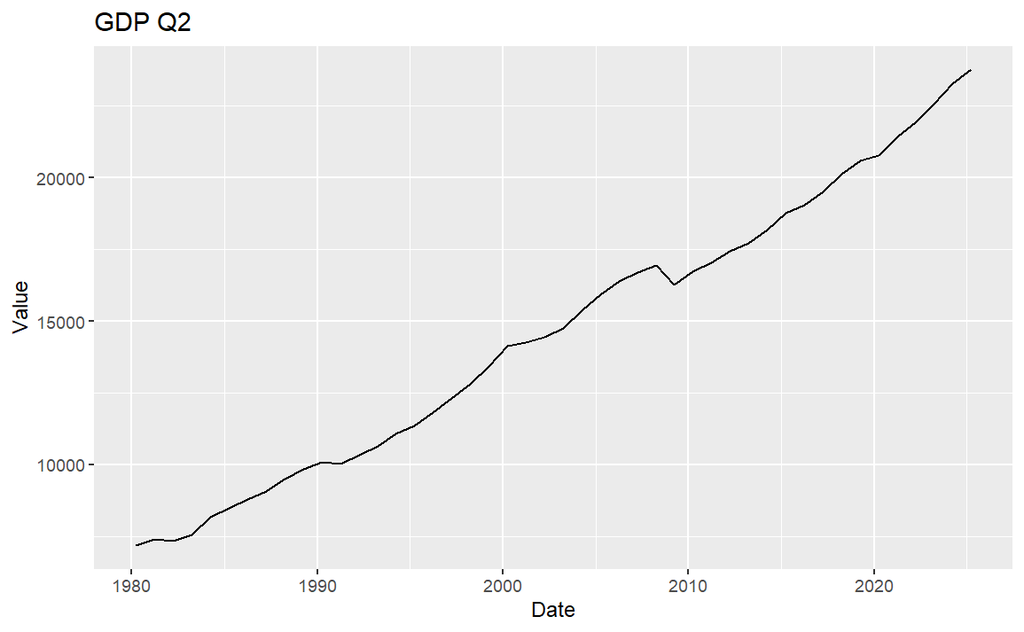

```r
gdp_full %>% filter(q == 2) %>% ggplot(aes(x=date, y=hampel_val)) + geom_line() + labs(title = "GDP Q2", x = "Date", y = "Value")
```

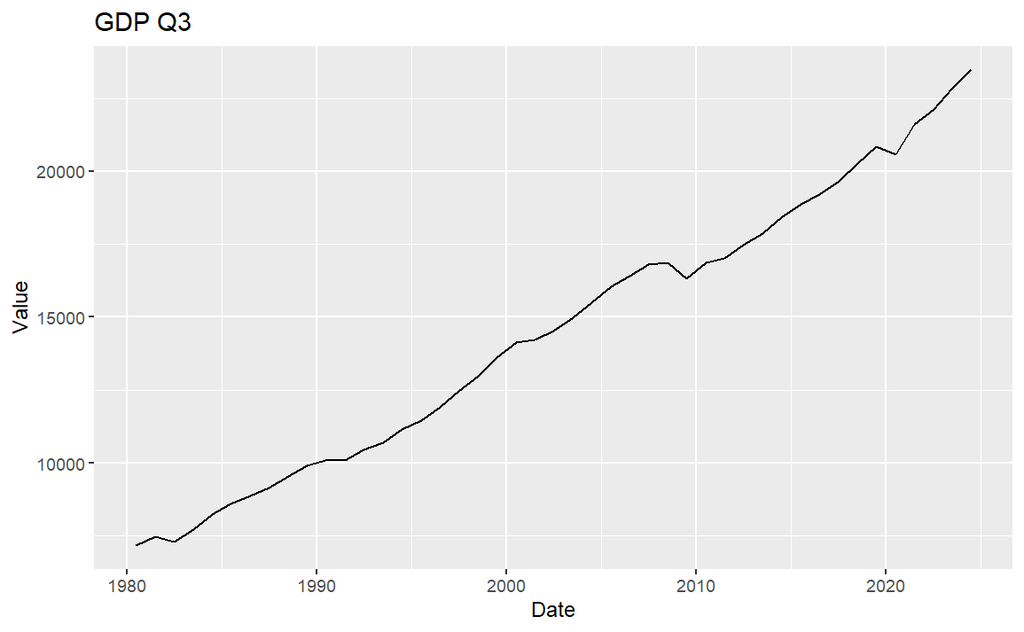

```r
gdp_full %>% filter(q == 3) %>% ggplot(aes(x=date, y=hampel_val)) + geom_line() + labs(title = "GDP Q3", x = "Date", y = "Value")
```

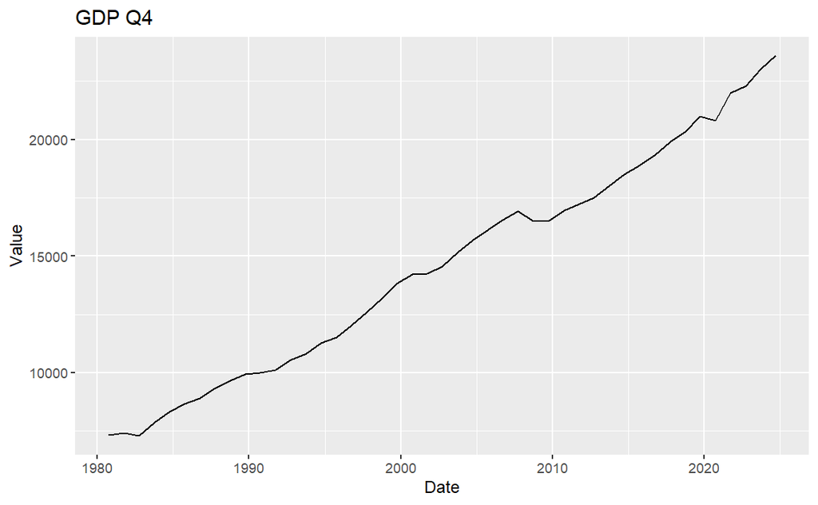

```r
gdp_full %>% filter(q == 4) %>% ggplot(aes(x=date, y=hampel_val)) + geom_line() + labs(title = "GDP Q4", x = "Date", y = "Value")
```

```r
start_year <- 1980
start_quarter <- 1

gdp_full_ts <- ts(gdp_full$hampel_val, start = c(start_year, start_quarter), frequency=4)

qs(gdp_full_ts)
```

```
Error in udg(x, qs.var, fail = FALSE) : inherits(x, "seas") is not TRUE
```

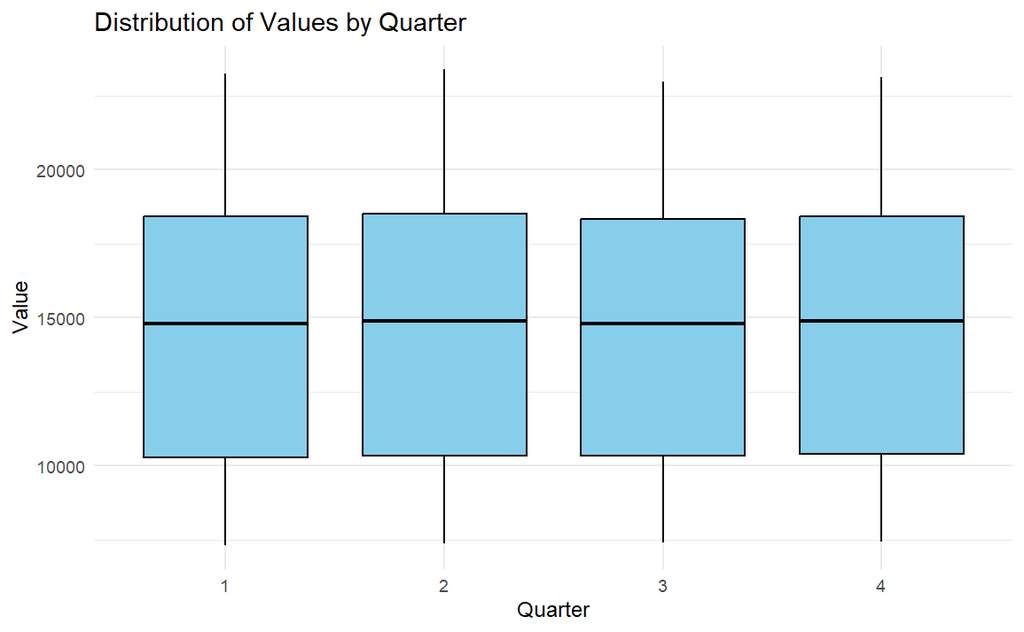

```r
pot_gdp_full <- pot_gdp_full %>% mutate(q = quarter(date))

pot_gdp_full$q_factor <- factor(pot_gdp_full$q, levels = c("1", "2", "3", "4"))

ggplot(pot_gdp_full, aes(x = q_factor, y = value)) +
  geom_boxplot(fill = "skyblue", color = "black") +
  labs(title = "Distribution of Values by Quarter",
       x = "Quarter",
       y = "Value") +
  theme_minimal()
```

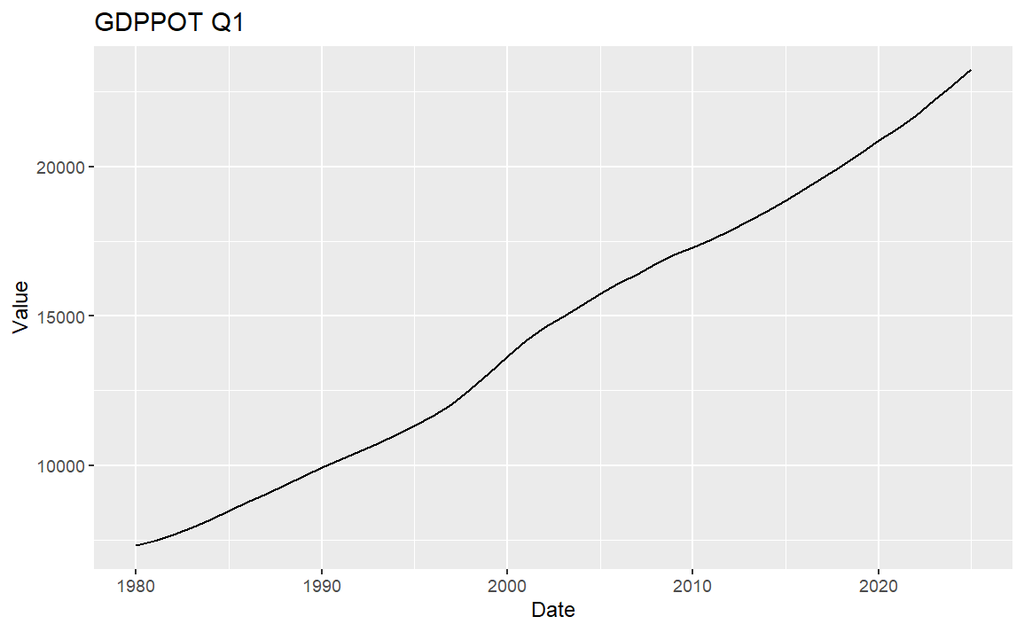

```r
pot_gdp_full %>% filter(q == 1) %>% ggplot(aes(x=date, y=hampel_val)) + geom_line() + labs(title = "GDPPOT Q1", x = "Date", y = "Value")
```

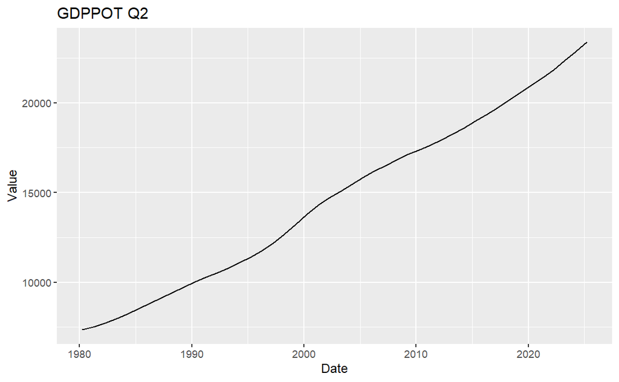

```r
pot_gdp_full %>% filter(q == 2) %>% ggplot(aes(x=date, y=hampel_val)) + geom_line() + labs(title = "GDPPOT Q2", x = "Date", y = "Value")
```

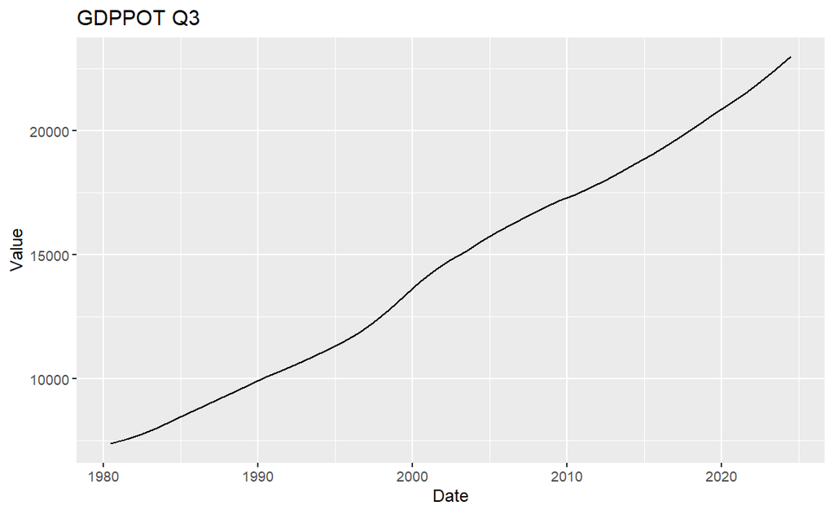

```r
pot_gdp_full %>% filter(q == 3) %>% ggplot(aes(x=date, y=hampel_val)) + geom_line() + labs(title = "GDPPOT Q3", x = "Date", y = "Value")
```

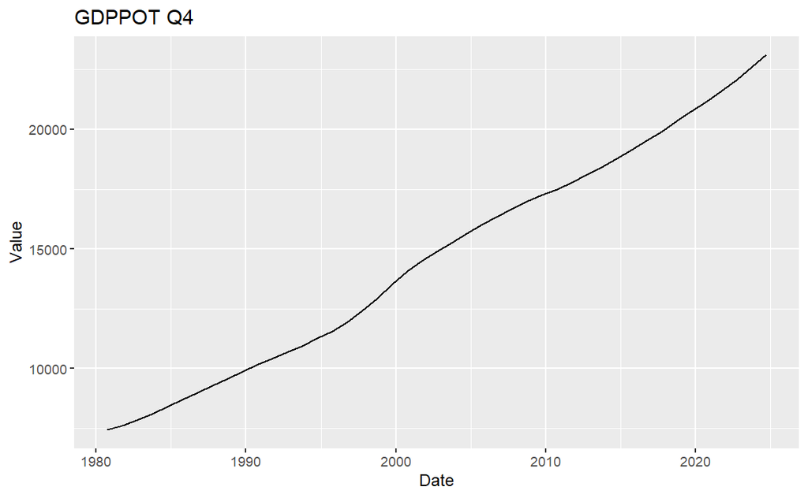

```r
pot_gdp_full %>% filter(q == 4) %>% ggplot(aes(x=date, y=hampel_val)) + geom_line() + labs(title = "GDPPOT Q4", x = "Date", y = "Value")
```

```r
start_year <- 1980
start_quarter <- 1

pot_gdp_full_ts <- ts(pot_gdp_full$hampel_val, start = c(start_year, start_quarter), frequency=4)

qs(pot_gdp_full_ts)
```

```
Error in udg(x, qs.var, fail = FALSE) : inherits(x, "seas") is not TRUE
```

Seasonal Adjustment via **X-13ARIMA-SEATS**

```r
pcepi_fit <- seas(pcepi_ts)

pcepi_full$s_adj_val <- final(pcepi_fit)

pot_gdp_fit <- seas(pot_gdp_full_ts)
```

```
Model used in SEATS is different: (0 2 2)
```

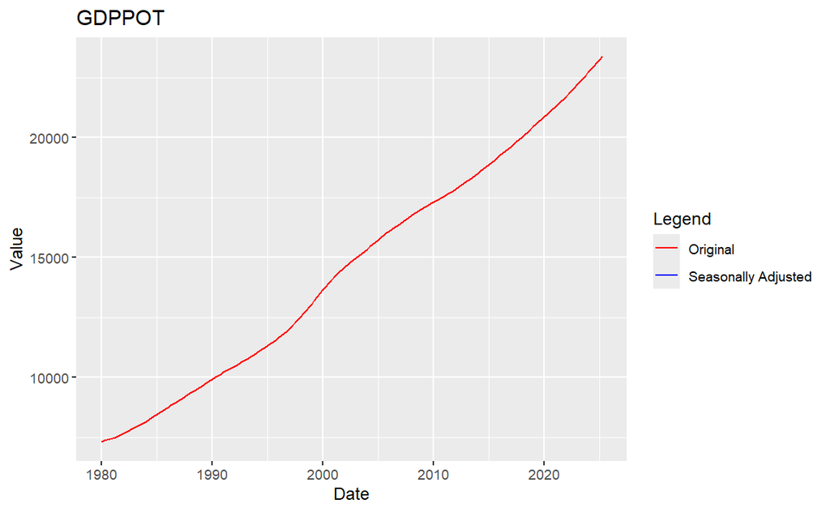

```r
pot_gdp_full$s_adj_val <- final(pot_gdp_fit)


pot_gdp_full %>%
  ggplot(aes(x = date)) +
  geom_line(aes(y = s_adj_val, color = "Seasonally Adjusted")) +
  geom_line(aes(y = value, color = "Original")) +
  labs(title = "GDPPOT",
       x = "Date",
       y = "Value") +
  scale_color_manual(values = c("Seasonally Adjusted" = "blue", "Original" = "red"),
                     name = "Legend")
```

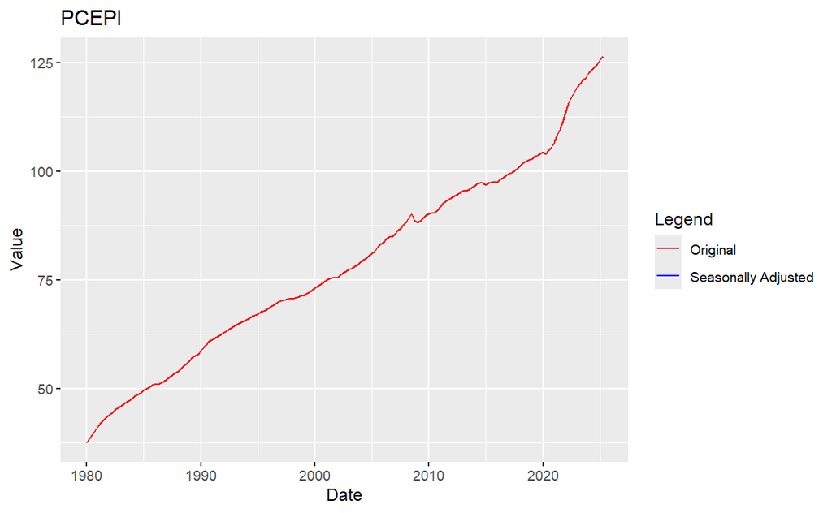

```r
pcepi_full %>%
  ggplot(aes(x = date)) +
  geom_line(aes(y = s_adj_val, color = "Seasonally Adjusted")) +
  geom_line(aes(y = value, color = "Original")) +
  labs(title = "PCEPI",
       x = "Date",
       y = "Value") +
  scale_color_manual(values = c("Seasonally Adjusted" = "blue", "Original" = "red"),
                     name = "Legend")
```

# Task 4

```r
infl_data <- ffer_full %>%
  select(date, value) %>%
  rename(FEDFUNDS = value) %>%
  left_join(pcepi_full, by = "date") %>%
  select(date, FEDFUNDS, value, pct_chg_pce) %>%
  rename(PCEPI = value) %>%
  left_join(gdp_full, by = "date") %>%
  select(date, FEDFUNDS, PCEPI, pct_chg_pce, value) %>%
  rename(GDPC1 = value) %>%
  left_join(pot_gdp_full, by = "date") %>%
  select(date, FEDFUNDS, PCEPI, pct_chg_pce, GDPC1, value) %>%
  rename(GDPPOT = value) %>%
  mutate(output_gap = 100 * (GDPC1 - GDPPOT) / GDPPOT)
```